# How To Make A Plot From Data

## *Bridget Haney*

### *June 13, 2019*

## 00 | How to Start

Wondering how to make a plot based on a certain dataset? Making a plot is simple, but it requires knowledge of how to extract data values and implement the plot in a readable way.

First, to even begin, you will need a few different R libraries. To filter and extract out certain data, the dplyr library will be most effective. To plot data in a visually-appealing form, ggplot2. To read in your csv file, or other relevant data files, data.table and R.utils are helpful and quick. The fread command comes from the data.table library. If any of these are not downloaded to your Rstudio, go ahead and install them using the install.packages(package) function. The top of your document should look like this:

```r
library(dplyr)
```

```r
library(ggplot2)
library(data.table)
library(R.utils)
data <- fread("any_drinking.csv", stringsAsFactors = FALSE)
```

## 01 | Filtering out Data from Datasets

From here, you can begin to filter out data. The dplyr library functions are where the filtering, selecting, and manipulating of data can occur. For instance, let’s extract out two different columns of data, labeled “males_2012” and “females_2012” for the state of Texas. The filter function will extract out all of the rows of Texas data, while the select function will take care of extracting the columns of gender-specific data.

```r
texas_data <- data %>%
              filter(state == "Texas")

males <- texas_data %>%
         select("males_2012")

females <- texas_data %>%
           select("females_2012")
```

You can look then at the first five values of your filtered data with the head function. The dataset comes first within the function, while the number of values you want to look at comes second.

```r
   head(males, 5)
```

```
##   males_2012
## 1       52.3
## 2       54.6
## 3       50.6
## 4       62.8
## 5       51.2
```

```r
   head(females, 5)
```

```
##   females_2012
## 1         35.5
## 2         35.3
## 3         34.9
## 4         46.4
## 5         33.5
```

## 02 | Plotting Your Data

Once establishing the data you want to look at, you can now create a meaningful plot to reflect your findings. Ggplot2 is a helpful, aesthetically pleasing way to demonstrate trends or other interesting analyses. We can do a scatterplot comparison of whether males or females in Texas tended to drink more in 2012. Here is the code and plot :

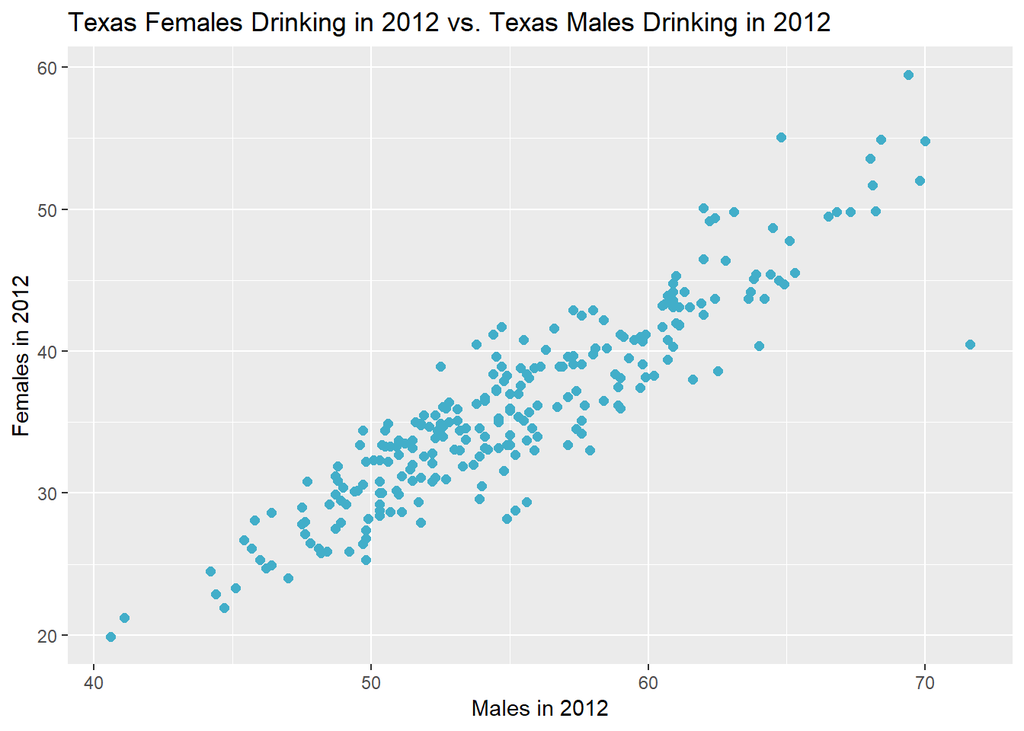

```r
ggplot(data = texas_data) +
      geom_point(aes(x= males_2012, y= females_2012), col = "#42aec9", size = 2) +
      ggtitle("Texas Females Drinking in 2012 vs. Texas Males Drinking in 2012") +
      xlab("Males in 2012") +
      ylab("Females in 2012")
```

Now, let us deconstruct the code. Below is a bulleted list of all of the functions and values within the code and their meaning:

- **ggplot**: The function in which the visual plot is ultimately created. Contained within this is the targeted dataset of values you want to plot.
- **geom_point**: The function that creates the visual plotted data points.
- **aes**: The function found within the geom_point function that is defined directly how it is abbreviated. It provides the mapping of the X and Y data values to the aesthetics or  
  visualizations of the plot.
- **col**: Value also within the geom_point function that stands for color. You can change this to whatever color, whether just keeping it to a default black, “Blue”, or a hex color code, like the one provided in the example code.
- **size**: Value within the geom_point function that changes the size of the points. Adding “.” in front of the number value is as if you are taking a certain percent of the default size. This makes the size smaller than the original default size. Making the size “2” or larger makes the values of the size greater than the original.
- **ggtitle**: The main title that goes over the plot. It provides users with the context of the data.
- **xlab**: The label of the x-axis.
- **y-lab**: The label of the y-axis.

Notice how all of the functions are separated by a **+** sign. These commands are ultimately added together to create the full plot and its looks.

## 03 | Overall Example of What We Learned

Let us now filter out and plot data on binge drinking in Washington in 2010! Use this as another guide to your future endeavors with ggplot2.

```r
binge_data <- fread("binge_drinking.csv", stringsAsFactors = FALSE)

washington_data <- binge_data %>%
                   filter(state == "Washington")

female_binge <- washington_data %>%
                select("females_2010")

male_binge <- washington_data %>%
              select("males_2010")

head(female_binge, 6)
```

```
##   females_2010
## 1          6.5
## 2         12.4
## 3         11.2
## 4         11.5
## 5         12.9
## 6         12.4
```

```r
head(male_binge, 6)
```

```
##   males_2010
## 1       23.4
## 2       25.2
## 3       24.1
## 4       22.3
## 5       22.4
## 6       23.0
```

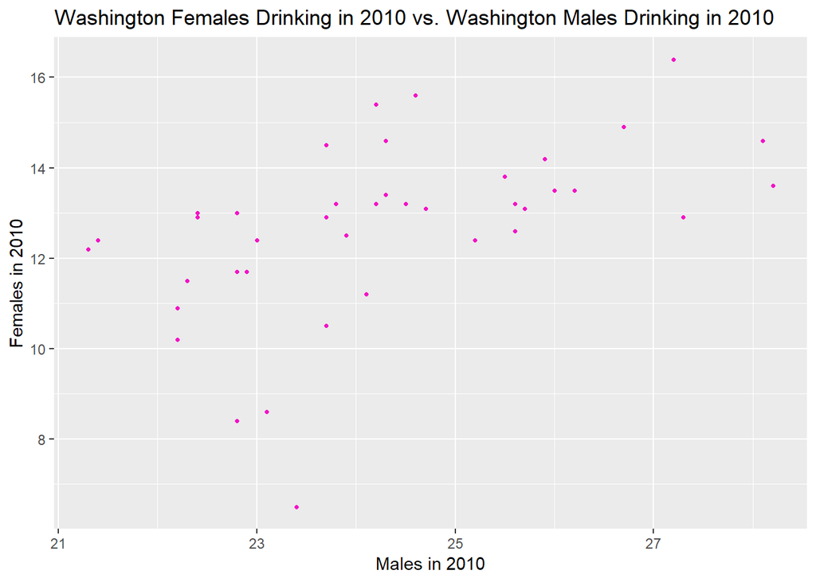

```r
ggplot(data = washington_data) +
      geom_point(aes(x= males_2010, y= females_2010), col = "#F312C6", size = .9) +
      ggtitle("Washington Females Drinking in 2010 vs. Washington Males Drinking in 2010") +
      xlab("Males in 2010") +
      ylab("Females in 2010")
```

## Analysis of Our Findings

After plotting data and seeing the trends, it is always important to impart your research onto those interested. According to the plots we created, it seems as though males typically drink more than females. The rate of regular drinking, versus binge drinking, is also higher. Generally, there also seems to be a higher frequency of drinkers on the lower end of the drinking spectrum than higher end.

Overall, when making plots for people to view, remember to use relevant titles and labels. Also, remember to explain in detail your process behind filtering and creating analysis about the data. Hopefully, this blog post is helpful to making plots!